# Space Missions Data Exploration

## by Christabel Onwuka

- Introduction
- Preliminary Wrangling
  - Gathering
  - Assessing
  - Cleaning
    - Issue #1: Missing Data
    - Issue #2: Tidiness
    - Issue #3: Quality
- Univariate Exploration
- Bivariate Exploration
- Multivariate Exploration
- Conclusions

## Introduction

This dataset contains information on all the space missions in human history (from 1957 to August 2022). It was gotten from [Maven Analytics Data Playground.](https://www.mavenanalytics.io/data-playground)

The dataset will be wrangled, analyzed and visualized to find out the patterns and trends in mission status of space missions, rocket status and price over the years and across countries.

*Table of Contents*

## Preliminary Wrangling

### Gathering Data

```python
# importing all packages and setting plots to be embedded inline
import numpy as np
import pandas as pd
import matplotlib.pyplot as plt
import seaborn as sb
from pandas.api.types import CategoricalDtype


%matplotlib inline
# setting seaborn grid style
sb.set_style('darkgrid')
```

```python
# loading the dataset
space_missions = pd.read_csv('space_missions.csv')
space_missions.head()
```

|  | Company | Location | Date | Time | Rocket | Mission | RocketStatus | Price | MissionStatus |
| --- | --- | --- | --- | --- | --- | --- | --- | --- | --- |
| 0 | RVSN USSR | Site 1/5, Baikonur Cosmodrome, Kazakhstan | 1957-10-04 | 19:28:00 | Sputnik 8K71PS | Sputnik-1 | Retired | NaN | Success |
| 1 | RVSN USSR | Site 1/5, Baikonur Cosmodrome, Kazakhstan | 1957-11-03 | 02:30:00 | Sputnik 8K71PS | Sputnik-2 | Retired | NaN | Success |
| 2 | US Navy | LC-18A, Cape Canaveral AFS, Florida, USA | 1957-12-06 | 16:44:00 | Vanguard | Vanguard TV3 | Retired | NaN | Failure |
| 3 | AMBA | LC-26A, Cape Canaveral AFS, Florida, USA | 1958-02-01 | 03:48:00 | Juno I | Explorer 1 | Retired | NaN | Success |
| 4 | US Navy | LC-18A, Cape Canaveral AFS, Florida, USA | 1958-02-05 | 07:33:00 | Vanguard | Vanguard TV3BU | Retired | NaN | Failure |

### Column names and their description

- **Company**: Company responsible for the space mission
- **Location**: Location of the launch
- **Date**: Date of the launch
- **Time**: Time of the launch (UTC)
- **Rocket**: Name of the rocket used for the mission
- **Mission**: Name of the space mission (or missions)
- **RocketStatus**: Status of the rocket as of August 2022 (Active or Inactive)
- **Price**: Cost of the rocket in millions of US dollars
- **MissionStatus**: Status of the mission (Success, Failure, Partial Failure, Prelaunch Failure)

### Assessing Data

```python
# checking for number of columns and rows
# and summary of information on the dataset
print(space_missions.shape)
space_missions.info()
```

```
(4630, 9)
<class 'pandas.core.frame.DataFrame'>
RangeIndex: 4630 entries, 0 to 4629
Data columns (total 9 columns):
 #   Column         Non-Null Count  Dtype
---  ------         --------------  -----
 0   Company        4630 non-null   object
 1   Location       4630 non-null   object
 2   Date           4630 non-null   object
 3   Time           4503 non-null   object
 4   Rocket         4630 non-null   object
 5   Mission        4630 non-null   object
 6   RocketStatus   4630 non-null   object
 7   Price          1265 non-null   object
 8   MissionStatus  4630 non-null   object
dtypes: object(9)
memory usage: 325.7+ KB
```

```python
# checking for the presence of null values in columns
space_missions.isnull().sum()
```

```
Company             0
Location            0
Date                0
Time              127
Rocket              0
Mission             0
RocketStatus        0
Price            3365
MissionStatus       0
dtype: int64
```

```python
# checking for duplicates
space_missions.duplicated().any()
```

```
True
```

```python
# checking the total number of duplicates in the dataset
space_missions.duplicated().sum()
```

```
1
```

```python
# info on the duplicate row
space_missions[space_missions.duplicated()]
```

|  | Company | Location | Date | Time | Rocket | Mission | RocketStatus | Price | MissionStatus |
| --- | --- | --- | --- | --- | --- | --- | --- | --- | --- |
| 3531 | CASC | Site 9401 (SLS-2), Jiuquan Satellite Launch Ce... | 2008-11-05 | 00:15:00 | Long March 2D | Shiyan-3 & Chuangxin-1(02) | Active | 29.75 | Success |

```python
# checking to see duplicate in the dataframe
space_missions.iloc[3529:3533]
```

|  | Company | Location | Date | Time | Rocket | Mission | RocketStatus | Price | MissionStatus |
| --- | --- | --- | --- | --- | --- | --- | --- | --- | --- |
| 3529 | CASC | LC-2, Xichang Satellite Launch Center, China | 2008-10-29 | 16:53:00 | Long March 3B/E | VENESAT 1 | Active | 29.15 | Success |
| 3530 | CASC | Site 9401 (SLS-2), Jiuquan Satellite Launch Ce... | 2008-11-05 | 00:15:00 | Long March 2D | Shiyan-3 & Chuangxin-1(02) | Active | 29.75 | Success |
| 3531 | CASC | Site 9401 (SLS-2), Jiuquan Satellite Launch Ce... | 2008-11-05 | 00:15:00 | Long March 2D | Shiyan-3 & Chuangxin-1(02) | Active | 29.75 | Success |
| 3532 | NASA | LC-39A, Kennedy Space Center, Florida, USA | 2008-11-15 | 00:55:00 | Space Shuttle Endeavour | STS-126 | Retired | 450 | Success |

*Quality Issues*

- Missing values in `Time` and `Price` columns
- Erroneous column datatypes (`Date`, `Time`, `RocketStatus`, `Price`, and `MissionStatus`)
  - Datetime: `Date` and `Time`
  - Categorical: `RocketStatus`(Active or Inactive) and `MissionStatus` (Success, Failure, Partial Failure, Prelaunch Failure))
  - Numerical/Float: `Price`
- One duplicate (index number: 3531)
- Change column names to lowercase

*Tidiness Issues*

- Launch site and country should be separated from the `Location` column into two columns
- `Date` and `Time` should be combined to one column
- **Other**: A column for year to be created

*Table of Contents*

### Cleaning Data

```python
# making a copy of original data
# and another copy where nulls will not be dropped
space_missions_clean = space_missions.copy()
space_w_nulls = space_missions.copy()
```

### Issue #1: Missing Data

- *Missing values in `Time` and `Price` columns*

*Define*:

Drop all null values in the `Time` and `Price` columns for uniformity of data so that only non-null values are analyzed and visualized (for only one copy of the dataset, `space_missions_clean`)

*Code*

```python
# using `.dropna()` to drop all null values from the dataset
space_missions_clean.dropna(inplace=True)
```

*Test*

```python
# testing to see that code worked
space_missions_clean.isnull().sum()
```

```
Company          0
Location         0
Date             0
Time             0
Rocket           0
Mission          0
RocketStatus     0
Price            0
MissionStatus    0
dtype: int64
```

```python
space_missions_clean.info()
```

```
<class 'pandas.core.frame.DataFrame'>
Int64Index: 1259 entries, 303 to 4629
Data columns (total 9 columns):
 #   Column         Non-Null Count  Dtype
---  ------         --------------  -----
 0   Company        1259 non-null   object
 1   Location       1259 non-null   object
 2   Date           1259 non-null   object
 3   Time           1259 non-null   object
 4   Rocket         1259 non-null   object
 5   Mission        1259 non-null   object
 6   RocketStatus   1259 non-null   object
 7   Price          1259 non-null   object
 8   MissionStatus  1259 non-null   object
dtypes: object(9)
memory usage: 98.4+ KB
```

*Table of Contents*

### Issue #2: Tidiness Issues

- *Launch site and country should be separated from the `Location` column into its own column*
- *`Date` and `Time` should be combined to one column*
- **Other**: A column for year to be created

*1. Launch site and country should be separated from the `Location` column into its own column*

*Define*:

Create two columns `Launch_Site` and `Country` from the `Location` column using `.rsplit()` function. Remove white space character from the `Country` column. Then, drop the `Location` column.

*Code*

```python
# splitting the `Location` column into new columns, `Site` and `Country`
space_missions_clean[['Launch_Site', 'Country']] = space_missions_clean['Location'].str.rsplit(',', expand=True, n=1)
space_w_nulls[['Launch_Site', 'Country']] = space_w_nulls['Location'].str.rsplit(',', expand=True, n=1)

# stripping white space character off the `Country` column values
space_missions_clean['Country'] = space_missions_clean['Country'].str.strip()
space_w_nulls['Country'] = space_w_nulls['Country'].str.strip()

# dropping the `Location` column
space_missions_clean.drop('Location', axis=1, inplace=True)
space_w_nulls.drop('Location', axis=1, inplace=True)
```

*Test*

```python
#testing to see that the codes worked
print(list(space_w_nulls))
list(space_missions_clean)
```

```
['Company', 'Date', 'Time', 'Rocket', 'Mission', 'RocketStatus', 'Price', 'MissionStatus', 'Launch_Site', 'Country']
```

```
['Company',
 'Date',
 'Time',
 'Rocket',
 'Mission',
 'RocketStatus',
 'Price',
 'MissionStatus',
 'Launch_Site',
 'Country']
```

*2. `Date` and `Time` should be combined to one column*

*Define*:

Convert only the `Date` datatype to datetime. Then, drop `Time` column as combining the null values of the *Time* to *Date* deletes all `Date` data in the dataset copy we are allowing to have null values (i.e. `space_w_nulls`). Also, `Time` will not be used in the analysis.

*Code*

```python
# converting `Date` to datetime dtype
space_missions_clean['Date'] = pd.to_datetime(space_missions_clean['Date'])
space_w_nulls['Date'] = pd.to_datetime(space_w_nulls['Date'])

# dropping `Time` column
col = ['Time']
space_missions_clean.drop(col, axis=1, inplace=True)
space_w_nulls.drop(col, axis=1, inplace=True)
```

*Test*

```python
# testing for clean dataset
space_missions_clean.info()
```

```
<class 'pandas.core.frame.DataFrame'>
Int64Index: 1259 entries, 303 to 4629
Data columns (total 9 columns):
 #   Column         Non-Null Count  Dtype
---  ------         --------------  -----
 0   Company        1259 non-null   object
 1   Date           1259 non-null   datetime64[ns]
 2   Rocket         1259 non-null   object
 3   Mission        1259 non-null   object
 4   RocketStatus   1259 non-null   object
 5   Price          1259 non-null   object
 6   MissionStatus  1259 non-null   object
 7   Launch_Site    1259 non-null   object
 8   Country        1259 non-null   object
dtypes: datetime64[ns](1), object(8)
memory usage: 98.4+ KB
```

```python
# for dataset with nulls
space_w_nulls.info()
```

```
<class 'pandas.core.frame.DataFrame'>
RangeIndex: 4630 entries, 0 to 4629
Data columns (total 9 columns):
 #   Column         Non-Null Count  Dtype
---  ------         --------------  -----
 0   Company        4630 non-null   object
 1   Date           4630 non-null   datetime64[ns]
 2   Rocket         4630 non-null   object
 3   Mission        4630 non-null   object
 4   RocketStatus   4630 non-null   object
 5   Price          1265 non-null   object
 6   MissionStatus  4630 non-null   object
 7   Launch_Site    4630 non-null   object
 8   Country        4630 non-null   object
dtypes: datetime64[ns](1), object(8)
memory usage: 325.7+ KB
```

*3.* *Other*: *A column for year to be created*

*Define:*

Create a new column, `Year`, to contain year values from the `Date` column. Then, reorder all columns of the dataset while at it.

*Code*

```python
# creating out `Year` column from the `Date_Time` column
space_missions_clean['Year'] = space_missions_clean['Date'].dt.year
space_w_nulls['Year'] = space_w_nulls['Date'].dt.year

# re-ordering all columns of the dataset
reordered_cols = ['Company', 'Launch_Site', 'Country', 'Date', 'Rocket', 'Price', 'RocketStatus', 'Mission', 'MissionStatus', 'Year']
space_missions_clean = space_missions_clean.reindex(columns=reordered_cols)
space_w_nulls = space_w_nulls.reindex(columns=reordered_cols)
```

*Test*

```python
space_missions_clean.head()
```

|  | Company | Launch_Site | Country | Date | Rocket | Price | RocketStatus | Mission | MissionStatus | Year |
| --- | --- | --- | --- | --- | --- | --- | --- | --- | --- | --- |
| 303 | US Air Force | SLC-20, Cape Canaveral AFS, Florida | USA | 1964-09-01 | Titan IIIA | 63.23 | Retired | Transtage 1 | Failure | 1964 |
| 323 | US Air Force | SLC-20, Cape Canaveral AFS, Florida | USA | 1964-12-10 | Titan IIIA | 63.23 | Retired | Transtage 2 | Success | 1964 |
| 330 | US Air Force | SLC-20, Cape Canaveral AFS, Florida | USA | 1965-02-11 | Titan IIIA | 63.23 | Retired | LES 1 | Success | 1965 |
| 352 | US Air Force | SLC-20, Cape Canaveral AFS, Florida | USA | 1965-05-06 | Titan IIIA | 63.23 | Retired | LES 2 & LCS 1 | Success | 1965 |
| 468 | US Air Force | SLC-4W, Vandenberg AFB, California | USA | 1966-07-29 | Titan IIIB | 59 | Retired | KH-8 | Success | 1966 |

*Table of Contents*

### Issue #3: Quality Issues

- *Erroneous column datatypes (`Date`, `Time`, `RocketStatus`, `Price`, and `MissionStatus`)*
  - Datetime: `Date` and `Time`
  - Categorical: `RocketStatus`(Active or Inactive) and `MissionStatus` (Success, Failure, Partial Failure, Prelaunch Failure)
  - Numerical/Float: `Price`
  - *Note* : Now that a new `Country` column has been created, convert to categorical datatype.
- *One duplicate (index number: 3531)*
- *Change column names to lowercase*

*1. Erroneous datatypes (`Date`, `Time`, `RocketStatus`, `Price`, and `MissionStatus`...plus `Country`)*

*Define*:

Change `RocketStatus` and `Country` to *unordered categorical* datatypes, `MissionStatus` to *ordered categorical* datatype and `Price` to *float* datatype. `Date`has already been converted to datetime datatype and `Time` has been dropped, so they won't be addressed here.

*Code*

```python
# converting `RocketStatus` and `Country` to unordered categorical dtype
unordered_cat_columns = ['RocketStatus', 'Country']
space_missions_clean[unordered_cat_columns] = space_missions_clean[unordered_cat_columns].astype('category')
space_w_nulls[unordered_cat_columns] = space_w_nulls[unordered_cat_columns].astype('category')

# converting `MissionStatus` to ordered categorical dtype
ordinal_status = ['Prelaunch Failure','Partial Failure', 'Failure', 'Success']
cat_type = CategoricalDtype(categories= ordinal_status, ordered=True)
space_missions_clean['MissionStatus'] = space_missions_clean['MissionStatus'].astype(cat_type)
space_w_nulls['MissionStatus'] = space_w_nulls['MissionStatus'].astype(cat_type)

# converting`Price` to float dtype
space_missions_clean['Price'] = space_missions_clean['Price'].str.replace(',', '').astype('float')
space_w_nulls['Price'] = space_w_nulls['Price'].str.replace(',', '').astype('float')
```

*Test*

```python
space_missions_clean.dtypes
```

```
Company                  object
Launch_Site              object
Country                category
Date             datetime64[ns]
Rocket                   object
Price                   float64
RocketStatus           category
Mission                  object
MissionStatus          category
Year                      int64
dtype: object
```

```python
space_w_nulls.dtypes
```

```
Company                  object
Launch_Site              object
Country                category
Date             datetime64[ns]
Rocket                   object
Price                   float64
RocketStatus           category
Mission                  object
MissionStatus          category
Year                      int64
dtype: object
```

*2. One duplicate entry(index number: 3531)*

*Define*:

Check to see if duplicate entry is still present. If present, drop duplicated entry.

*Code*

```python
# checking if duplicate is still present
print(space_w_nulls.duplicated().sum())
space_missions_clean.duplicated().sum()
```

```
1
```

```
1
```

```python
# drop the duplicate row
space_missions_clean.drop_duplicates(inplace=True)
space_w_nulls.drop_duplicates(inplace=True)
```

*Test*

```python
# checking to see if duplicate was removed
print(space_w_nulls.duplicated().any())
space_missions_clean.duplicated().any()
```

```
False
```

```
False
```

*3. Change column names to lowercase*

*Define*:

Rename columns by separating long names with underscore and changing to lowercase.

*Code*

```python
# list of columns in dataset (before change)
list(space_missions_clean)
```

```
['Company',
 'Launch_Site',
 'Country',
 'Date',
 'Rocket',
 'Price',
 'RocketStatus',
 'Mission',
 'MissionStatus',
 'Year']
```

```python
# separate long-named column labels with `underscore`
space_missions_clean.rename(columns={'RocketStatus': 'Rocket_Status', 'MissionStatus': 'Mission_Status'}, inplace = True)
space_w_nulls.rename(columns={'RocketStatus': 'Rocket_Status', 'MissionStatus': 'Mission_Status'}, inplace = True)

# change all column labels to lowercase
space_missions_clean.rename(columns=lambda y: y.lower(), inplace=True)
space_w_nulls.rename(columns=lambda y: y.lower(), inplace=True)
```

*Test*

```python
# list of columns in dataset (after change)
print(list(space_w_nulls))
list(space_missions_clean)
```

```
['company', 'launch_site', 'country', 'date', 'rocket', 'price', 'rocket_status', 'mission', 'mission_status', 'year']
```

```
['company',
 'launch_site',
 'country',
 'date',
 'rocket',
 'price',
 'rocket_status',
 'mission',
 'mission_status',
 'year']
```

```python
space_missions_clean.info()
```

```
<class 'pandas.core.frame.DataFrame'>
Int64Index: 1258 entries, 303 to 4629
Data columns (total 10 columns):
 #   Column          Non-Null Count  Dtype
---  ------          --------------  -----
 0   company         1258 non-null   object
 1   launch_site     1258 non-null   object
 2   country         1258 non-null   category
 3   date            1258 non-null   datetime64[ns]
 4   rocket          1258 non-null   object
 5   price           1258 non-null   float64
 6   rocket_status   1258 non-null   category
 7   mission         1258 non-null   object
 8   mission_status  1258 non-null   category
 9   year            1258 non-null   int64
dtypes: category(3), datetime64[ns](1), float64(1), int64(1), object(4)
memory usage: 83.0+ KB
```

```python
space_w_nulls.info()
```

```
<class 'pandas.core.frame.DataFrame'>
Int64Index: 4629 entries, 0 to 4629
Data columns (total 10 columns):
 #   Column          Non-Null Count  Dtype
---  ------          --------------  -----
 0   company         4629 non-null   object
 1   launch_site     4629 non-null   object
 2   country         4629 non-null   category
 3   date            4629 non-null   datetime64[ns]
 4   rocket          4629 non-null   object
 5   price           1264 non-null   float64
 6   rocket_status   4629 non-null   category
 7   mission         4629 non-null   object
 8   mission_status  4629 non-null   category
 9   year            4629 non-null   int64
dtypes: category(3), datetime64[ns](1), float64(1), int64(1), object(4)
memory usage: 303.9+ KB
```

> **Note:** The `space_w_nulls` dataframe is the cleaned dataset with *no null value removed*. It will be used should the need arise later on. For now, the main dataset to be used in our analysis is `space_missions_clean` which is our cleaned dataset with *all nulls removed*.

```python
# descriptive statistics for numeric variables
space_missions_clean.describe()
```

|  | price | year |
| --- | --- | --- |
| count | 1258.000000 | 1258.000000 |
| mean | 128.860413 | 2010.622417 |
| std | 257.372270 | 12.259708 |
| min | 2.500000 | 1964.000000 |
| 25% | 30.200000 | 2006.000000 |
| 50% | 63.955000 | 2016.000000 |
| 75% | 120.000000 | 2019.000000 |
| max | 5000.000000 | 2022.000000 |

- Max price for a rocket is 5B(dollars) while the min for a rocket is 2.5M with the average price at around $128 million.
- Earliest year for missions was 1964 with most recent missions in 2022.

```python
list(space_missions_clean)
```

```
['company',
 'launch_site',
 'country',
 'date',
 'rocket',
 'price',
 'rocket_status',
 'mission',
 'mission_status',
 'year']
```

```python
# saving cleaned dataset to csv
space_missions_clean.to_csv('space_missions_master.csv', index=False)
```

*Table of Contents*

### What is the structure of your dataset?

There are 4630 space mission entries in the dataset with 9 columns. All variables pre-cleaning are non_numeric and contain null values in two columns with a duplicated row. After wrangling and cleaning, dataset pares down to **1258** mission entries with 10 features (company, launch_site, country, date, rocket, price, rocket_status, mission, mission_status, and year). The cleaned dataset has 2 numeric variables, 3 categorical variables and 4 object/string variables. Of the three categorical variables, one (`mission_status`) is an ordered categorical variable with the following levels:

(worst) ——> (best)

*`mission_status`*: Prelaunch Failure, Partial Failure, Failure, Success

### What is/are the main feature(s) of interest in your dataset?

The main feature of this dataset is the mission status of rockets as well the rocket status. I'm in interested in whether the success of space missions can be predicted by the variables in the dataset; and if so, the degree of prediction, and how it varies geographically across nations.

### What features in the dataset do you think will help support your investigation into your feature(s) of interest?

I expect to uncover the effect of price, year and rocket status in determining mission success and whether there is any noteworthy relationship between those variables.

*Table of Contents*

## Univariate Exploration

### Distributions of categorical variables

```python
# assigning color palette
base_color = sb.color_palette()[0] # default color
# other color for numeric variables for variety
num_color = sb.color_palette()[3]
```

```python
# defining a function to plot simple count without order argument set
def simple_count(column_name):
    """"This function plots a simple count of plots """
    base_color = sb.color_palette()[0]
    sb.countplot(data = space_missions_clean, x = column_name, color = base_color)
    plt.xlabel(f"{column_name.replace('_', ' ').title()}", fontsize=12)
    plt.ylabel("Count", fontsize=12)
    plt.title(f"Distribution of {column_name.replace('_', ' ').title()}", fontsize=15);
```

*For variable of interest, `mission_status`*

**How successful were space missions likely to be?**

```python
# count of unique values
space_missions_clean.mission_status.value_counts()
```

```
Success              1192
Failure                46
Partial Failure        19
Prelaunch Failure       1
Name: mission_status, dtype: int64
```

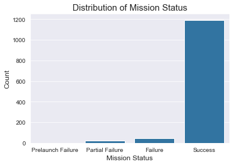

```python
# visualizing the counts
simple_count('mission_status')
```

There is a very high rate of successful missions with about 95% success rate.

*For `rocket_status`*

**How many rockets are still active?**

```python
# count of unique values
space_missions_clean.rocket_status.value_counts()
```

```
Active     863
Retired    395
Name: rocket_status, dtype: int64
```

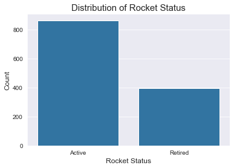

```python
# visualizing the counts
simple_count('rocket_status')
```

The number of active rockets is twice the number of retired rockets. About 68% of rockets are still active which is twice the number of rockets that are retired.

```python
# defining a function that plot counts with the order argument set
def ordered_counts(column_name):
    """Simple count of plots with the order argument set"""
    plt.figure(figsize=[12, 6])
    base_color = sb.color_palette()[0]
    ordered = space_missions_clean[column_name].value_counts().index
    plt.title(f"Frequency of {column_name.title()}", fontsize=15)
    if column_name == 'country':
        sb.countplot(data = space_missions_clean, y = column_name, color = base_color, order = ordered);
        plt.ylabel(f"{column_name.title()}", fontsize=12)
        plt.xlabel("Count", fontsize=12)
    else:
        sb.countplot(data = space_missions_clean, x = column_name, color = base_color, order = ordered);
        plt.xticks(rotation= 90)
        plt.xlabel(f"{column_name.title()}", fontsize=12)
        plt.ylabel("Count", fontsize=12)
```

*For `country`*

**How many missions do participating countries have?**

```python
# frequency of unique countries
space_missions_clean.country.value_counts()
```

```
USA             590
China           252
France          128
Russia           82
India            70
Kazakhstan       63
Japan            43
New Zealand      25
Yellow Sea        3
Gran Canaria      2
Name: country, dtype: int64
```

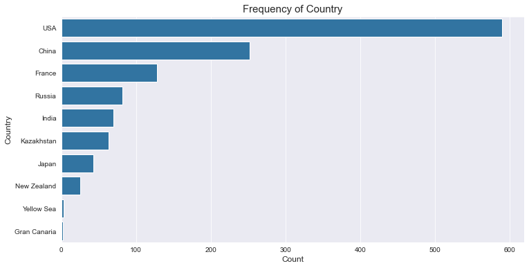

```python
# visualizing the counts
ordered_counts('country')
```

The USA has the most missions followed by China in second place with France in the third place

*For `company`*

```python
# frequency of unique companies
space_missions_clean.company.value_counts()
```

```
CASC               237
SpaceX             176
NASA               149
Arianespace        129
ULA                108
Northrop            89
ISRO                70
VKS RF              52
Roscosmos           40
MHI                 39
Rocket Lab          25
US Air Force        25
Kosmotras           20
ExPace              15
Eurockot            13
ILS                 13
Martin Marietta      9
Starsem              9
Lockheed             8
Boeing               7
Astra                7
Virgin Orbit         5
JAXA                 4
RVSN USSR            2
Galactic Energy      2
EER                  1
ESA                  1
Khrunichev           1
GK LS                1
CASIC                1
Name: company, dtype: int64
```

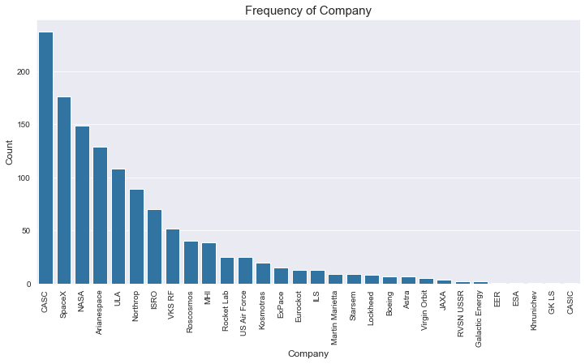

```python
# visualizing the counts
ordered_counts('company')
```

In this cleaned dataset, CASC (China Aerospace Science and Technology Corporation), China, is the company with most rockets at 237; followed by SpaceX, USA, with 176 rockets; NASA, USA, with 149 rockets; Arianespace, France, with 129; ULA and Northrop, USA with 108 and 89 rockets respectively.

### Distributions of numerical variables

*Plots for the collective distributions of the numeric variables*

A quick overview into relationship between numerical values.

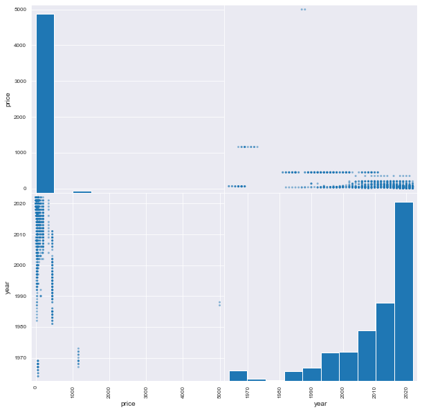

```python
pd.plotting.scatter_matrix(space_missions_clean, figsize=(10,10));
```

From the plot above, the dots represent the number of rockets bought at a given price in a given year. When the dots are bold, it indicates a high number of rockets bought. For example, in the third quadrant, the two faint dots on 5000M(USD) indicate that very few rockets (two rockets, precisely) were bought at that amount before the year 1990.

```python
# the rockets (two) bought at $5000M
space_missions_clean[space_missions_clean.price == 5000.0]
```

|  | company | launch_site | country | date | rocket | price | rocket_status | mission | mission_status | year |
| --- | --- | --- | --- | --- | --- | --- | --- | --- | --- | --- |
| 2323 | RVSN USSR | Site 250, Baikonur Cosmodrome | Kazakhstan | 1987-05-15 | Energiya/Polyus | 5000.0 | Retired | Polyus Space Station | Success | 1987 |
| 2407 | RVSN USSR | Site 110/37, Baikonur Cosmodrome | Kazakhstan | 1988-11-15 | Energiya/Buran | 5000.0 | Retired | Buran | Success | 1988 |

Histograms of numeric columns in the dataset

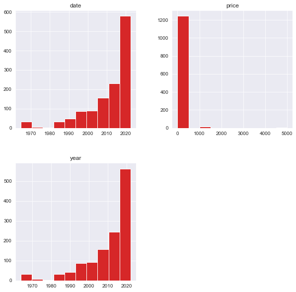

```python
# histograms of numerical variables with color set to [3] of seaborn's color palette
space_missions_clean.hist(figsize=(10,10), color = num_color);
```

From the plot above, we can see that:

- Very few rockets cost above 500M
- There were more space missions in the 2020's and very few between 1970 and 1980 (this is because the price values of the years between the 70's and 80's are null and have been dropped. A look at a copy of the data with nulls reveals otherwise as shown below.)

*Histograms of numeric columns in the dataset **with nulls**.*

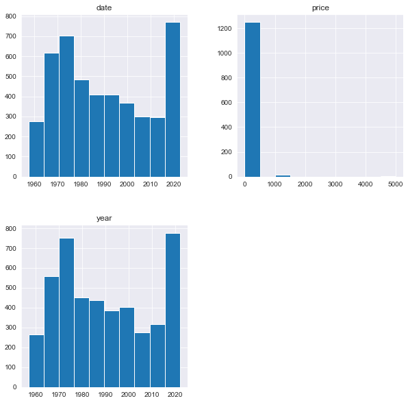

```python
# histograms of numeric variables in the dataset with null values present
space_w_nulls.hist(figsize=(10,10));
```

> The plot of the dataset with nulls reveals a high frequency of space missions from the 60's to the late 70's. Its frequency is almost close to the frequency of space missions in the 2022's. There seems to be a resurrgence of space missions in recent years.

*Plots for individual distributions of the numeric variables*

```python
# defining a function that plots a histogram of numerical variable with bins set to 20
def twenty_bin_hist(column_name):
    """This function plots a histogram of numerical variable with bins set to 20"""
    num_color = sb.color_palette()[3]
    plt.figure(figsize=[8, 5])
    plt.hist(data = space_missions_clean, x = column_name, bins = 20, color = num_color)
    if column_name == 'price':
        plt.xlabel(f"{column_name.title()} in million USD", fontsize=12)
    else:
        plt.xlabel(f"{column_name.title()}", fontsize=12)
    plt.ylabel("Frequency", fontsize=12)
    plt.title(f"Distribution of {column_name.title()}", fontsize=15);
```

*For `price`*

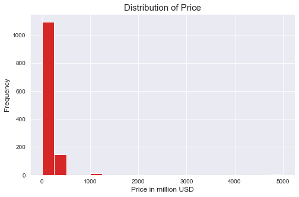

```python
# distribution of price with bins set to 20
twenty_bin_hist('price')
```

- *Checking the distribution of Price where rocket prices are mainly concentrated*

```python
# min, mean and max of price
space_missions_clean['price'].min(), space_missions_clean['price'].mean(), space_missions_clean['price'].max()
```

```
(2.5, 128.8604133545303, 5000.0)
```

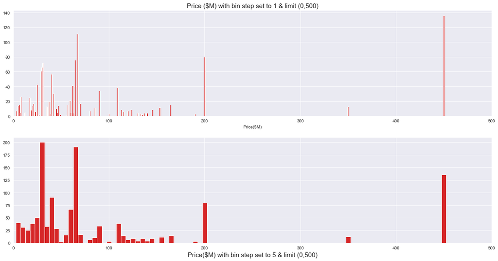

```python
plt.figure(figsize = [20, 10])

# histogram on left, bin step set to 1
plt.subplot(2, 1, 1) # 2 rows, 1 col, subplot 1
bins = np.arange(space_missions_clean['price'].min(), space_missions_clean['price'].max()+5, 1)
plt.hist(data = space_missions_clean, x = 'price', bins = bins, color = num_color)
plt.xlim((0,500))
plt.xlabel('Price($M)')
plt.title('Price ($M) with bin step set to 1 & limit (0,500)', fontsize = 15);

# histogram on right, bin step set to 50
plt.subplot(2, 1, 2) # 2 rows, 1 col, subplot 2
bins = np.arange(space_missions_clean['price'].min(), space_missions_clean['price'].max()+5, 5)
plt.hist(data = space_missions_clean, x = 'price', bins = bins, color = num_color)
plt.xlim((0,500))
plt.xlabel('Price($M) with bin step set to 5 & limit (0,500)', fontsize = 15);

plt.show()
```

The plot seems multi-modal with most rocket prices between 30 - 50M, 200 and 450M USD. Very few rockets cost between 1 billion (i.e. 1000 million USD) - 5 billion (5000 million USD) and are obviously *outliers*.

*For `year`*

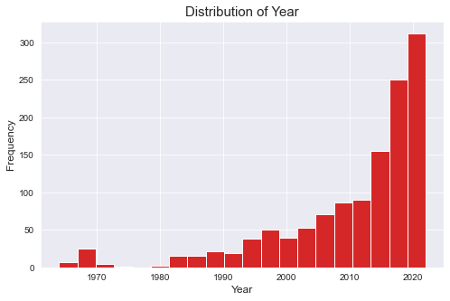

```python
# distribution of year with bins set to 20
twenty_bin_hist('year')
```

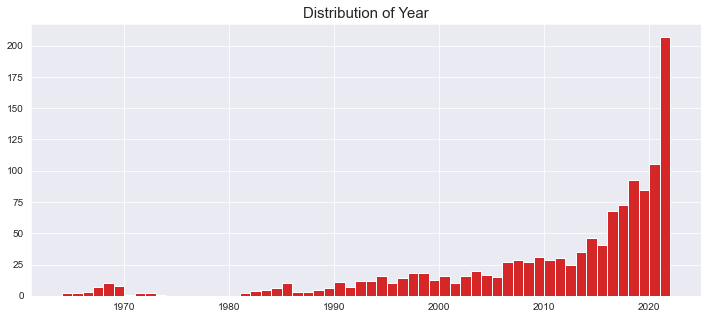

```python
# granular distribution, with a bin step of 1
plt.figure(figsize=[12, 5])
bins = np.arange(space_missions_clean['year'].min(), space_missions_clean['year'].max()+1, 1)
plt.hist(data = space_missions_clean, x = 'year', bins = bins, color = num_color);
plt.title("Distribution of Year", fontsize=15);
```

The plot above is left-skewed and shows that most missions took place in the 2020's with 2022 witnessing the most space missions.

### Discuss the distribution(s) of your variable(s) of interest. Were there any unusual points? Did you need to perform any transformations?

The distribution of the variable of interest, the `mission_status` shows that about 95% of missions were successful indicating a very high mission success rate with the number of active rockets twice the number of retired rockets and the USA being the country with the most launched space missions followed by China in second place and France in the third place.

### Of the features you investigated, were there any unusual distributions? Did you perform any operations on the data to tidy, adjust, or change the form of the data? If so, why did you do this?

Compared to the dataset with null values included, this cleaned dataset showed an unusual distribution of mission years with data on the decade that had null price values not appearing in the histogram, thereby obscuring the fact that there seems to be a resurgence in space mission programs in recent years.

Also, the distribution of the `price` seemed quite multi-modal. With an unusually high price for a rocket at 5 billion USD and the lowest price at 2.5 million dollars, most rocket prices lie below 500 million dollars showing peaks at various points.

*Table of Contents*

## Bivariate Exploration

### For numerical variables

```python
# setting numerical and categorical variables
num_vars = ['price', 'year']
cat_vars = ['mission_status', 'rocket_status', 'country']
```

```python
# setting uniform base color
base_color = sb.color_palette()[0]
# setting uniform other color for numeric variables for variety
num_color = sb.color_palette()[3]
```

*Relationship between the numeric variables `price` and `year`*

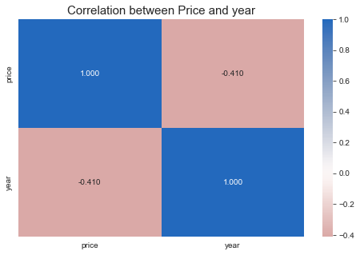

```python
# correlation plot of numerical variables
plt.figure(figsize = [8, 5])
sb.heatmap(space_missions_clean[num_vars].corr(), annot = True, fmt = '.3f',
           cmap = 'vlag_r', center = 0)
plt.title('Correlation between Price and year', fontsize=15);
plt.show()
```

The correlation between year and price signifies a weak negative correlation with *a correlation coefficient of* *-0.410*.

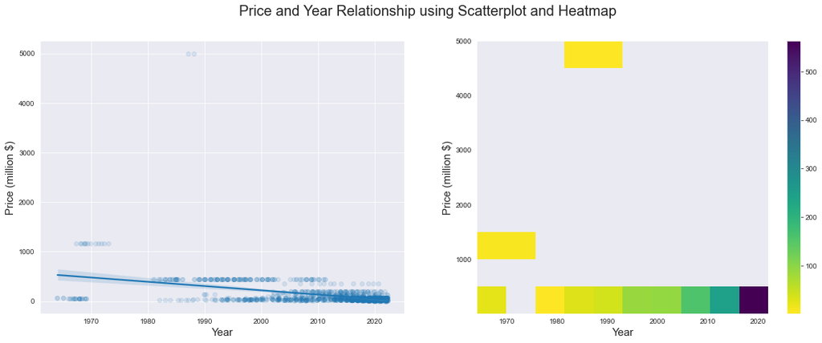

```python
plt.figure(figsize = [20, 7])
# figure title
plt.suptitle('Price and Year Relationship using Scatterplot and Heatmap', fontsize=20)

# Scatterplot on the left
plt.subplot(1, 2, 1)
sb.regplot(data = space_missions_clean, y = 'price', x = 'year', x_jitter = 0.3,
          scatter_kws = {'alpha' : 1/8});
plt.ylabel('Price (million $)', fontsize = 15)
plt.xlabel('Year', fontsize = 15);

# Heatmap plot on the right
plt.subplot(1, 2, 2)
plt.hist2d(data = space_missions_clean, x = 'year', y = 'price', cmin = 0.5,
          cmap = 'viridis_r');
plt.colorbar()
plt.xlabel('Year', fontsize = 15)
plt.ylabel('Price (million $)', fontsize = 15);
```

The plot shows that there is a weak negative correlation between year and price. The price of rockets have declined in recent years after the year 1990. The regression line indicates a downward trend in rocket prices over the years. From the late 2010's upwards, there is high density of rockets with lower prices in use.

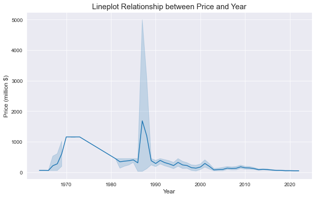

```python
# lineplot showing the relationship between `price` and `year`
plt.figure(figsize = [10, 6])
sb.lineplot(data = space_missions_clean, y = 'price', x = 'year');
plt.xlabel('Year', fontsize = 12)
plt.ylabel('Price (million $)', fontsize = 12);
plt.title('Lineplot Relationship between Price and Year', fontsize=15);
```

> The line plot also confirms a downward trend in prices across years after the year 1990. The peaks at approx. 1970 and around the late 80's signify the presence of outliers.

### For the relationship between numeric and categorical variables

```python
# defining function to plot the violin and boxplots of categorical and numeric variables"
def violin_boxplots(first_var, second_var):
    """A function that plots the violin and boxplots of categorical and numeric variables"""
    # setting uniform color
    base_color = sb.color_palette()[0]

    plt.figure(figsize = [12, 6])
    plt.suptitle(f"{first_var.replace('_', ' ').title()} vs. {second_var.replace('_', ' ').title()} Relationship", fontsize=15);


    country_plot_order = space_missions_clean.country.value_counts().index
    plt.subplot(1, 2, 1)
    if first_var == 'country':
        sb.violinplot(data = space_missions_clean, x = first_var, y = second_var,
              inner= 'quartile', color = base_color, order = country_plot_order)
        plt.xticks(rotation = 45);
    else:
        sb.violinplot(data = space_missions_clean, x = first_var, y = second_var, inner= 'quartile', color = base_color);
    plt.xlabel(f"{first_var.replace('_', ' ').title()}", fontsize=12)
    plt.ylabel(f"{second_var.replace('_', ' ').title()}", fontsize=12)


    plt.subplot(1, 2, 2)
    if first_var == 'country':
        sb.boxplot(data = space_missions_clean, x = first_var , y = second_var, color = base_color, order = country_plot_order)
        plt.xticks(rotation = 45);
    else:
        sb.boxplot(data = space_missions_clean, x = first_var, y = second_var, color = base_color);
    plt.xlabel(f"{first_var.replace('_', ' ').title()}", fontsize=12)
    plt.ylabel(f"{second_var.replace('_', ' ').title()}", fontsize=12)

    plt.show()
```

*`Mission status` vs `Year`*

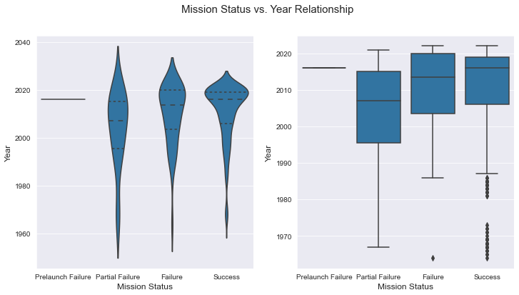

```python
violin_boxplots('mission_status', 'year')
```

So few rockets experienced a *Prelaunch Failure* and the ones that did occurred before 2020. The violin plot shows a high density of successful missions in the 2020's

*`Mission status` vs. `Price`*

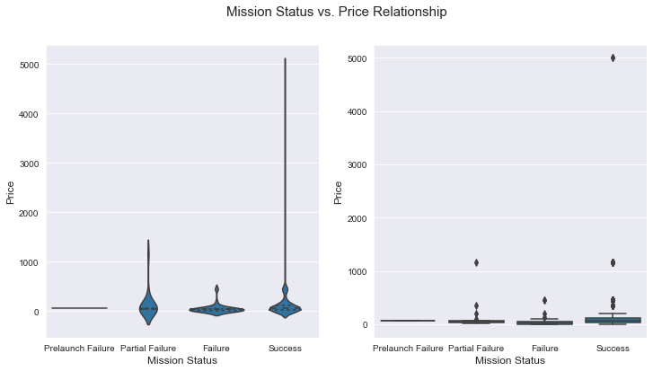

```python
violin_boxplots('mission_status', 'price')
```

The density of mission status levels occurring below 1000 and very close to zero(0) shows that the price of rockets does not determine the success rates of missions as there have been successful rockets above the 1000 price mark. Also, rockets with some sort of failure have prices above the 1000 price mark and within 0 - 1000 as well as shown in both plots.

*`Rocket status` vs. `Year`*

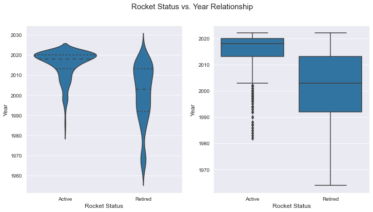

```python
violin_boxplots('rocket_status', 'year')
```

*`Rocket status` and `Price`*

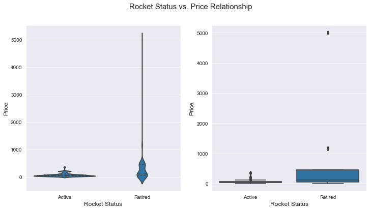

```python
violin_boxplots('rocket_status', 'price')
```

The rocket price range for active rockets lie below 500 million USD while the rockets with the outlier price range of 1000 - 5000 million USD have all been retired.

*`Country` vs. `Year`*

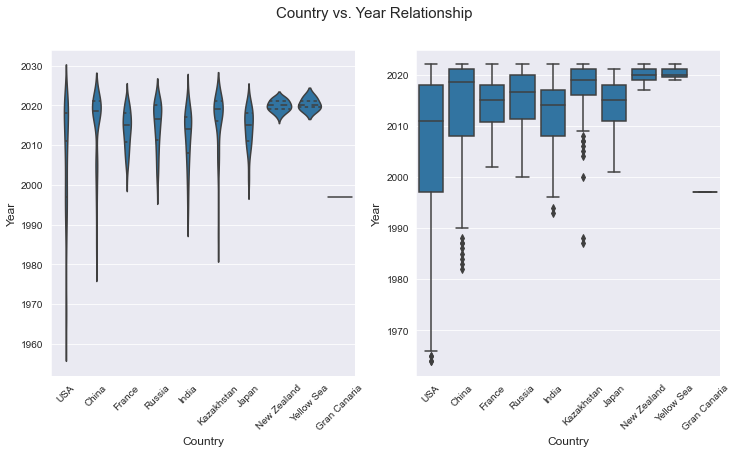

```python
violin_boxplots('country', 'year')
```

Though this data shows that Russia joined the space mission in 2000s, the original uncleaned dataset recorded the earliest date of Russian space mission to be 1961 and Kazakhstan (former USSR) to be 1957.

The plot above is for the cleaned dataset with **no missing values** in all columns. Apparently, the USA seems to be the only country with very few missing values from the beginning of the space race.

*`Country` vs. `Price`*

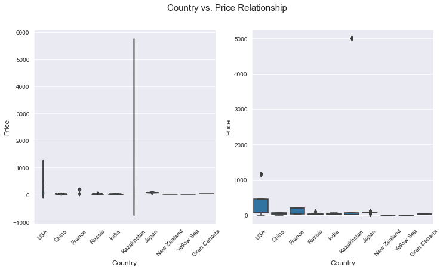

```python
violin_boxplots('country', 'price')
```

This plot shows Kazakhstan as the country with the outlier rocket price of 5000 million USD (5B dollars). The USA also has rockets in the price range of more than 1000 million USD (>$1B)

### For the relationship between categorical variables

*I will start by* *defining functions* *for clustered barchart, heatmap and their subplots.*

```python
# defining a function to plot a clustered bar chart of two cat variables
def clustered_barchart(first_var, second_var):
    """This function plots a clustered bar chart of two categorical variables"""
    if second_var == 'country':
        country_order = space_missions_clean.country.value_counts().index
        sb.countplot(data = space_missions_clean, x = first_var,
                     hue = 'country', hue_order = country_order)
    else:
        sb.countplot(data = space_missions_clean, x = first_var, hue = second_var);
    if first_var == 'mission_status':
        plt.legend(loc = 'upper left')
    else:
        plt.legend(loc = 'upper right');
    plt.xlabel(first_var.replace('_', ' ').title(), fontsize=12)
    plt.ylabel("Count", fontsize=12)
```

```python
# defining a function to plot a heatmap of two cat variables
def cat_heatmap(first_var, second_var):
    """This function plots a heatmap of two categorical variables"""
    # checking combination of variables with groupby() and size() as a pandas series
    ct_counts = space_missions_clean.groupby([first_var, second_var]).size()
    # converting the series into a dataframe with reset_index()
    ct_counts = ct_counts.reset_index(name = 'count')
    # rearranging data by pivoting into rows and columns with values in the cells
    ct_counts = ct_counts.pivot(index = first_var, columns = second_var, values = 'count')

    # plotting heatmap with the dataframe and annotating the counts in the cells as decimals
    sb.heatmap(ct_counts, annot = True, fmt = 'd');
    plt.xlabel(f"{second_var.replace('_', ' ').title()}", fontsize=12)
    plt.ylabel(f"{first_var.replace('_', ' ').title()}", fontsize=12)
```

```python
# defining a function that subplots the clustered bar and heatmap plot functions
def bar_heat_subplots(first_var, second_var):
    """This function to subplots the clustered bar chart and heatmap functions of two categorical variables"""
    plt.figure(figsize = [16, 8])
    plt.suptitle(f"Distribution in counts of {first_var.replace('_', ' ').title()} by {second_var.replace('_', ' ').title()} ", fontsize=18);

    plt.subplot(1, 2, 1)
    clustered_barchart(first_var, second_var)

    plt.subplot(1, 2, 2)
    cat_heatmap(first_var, second_var)

    plt.show()
```

*`Mission status` vs. `Rocket_status` relationship*

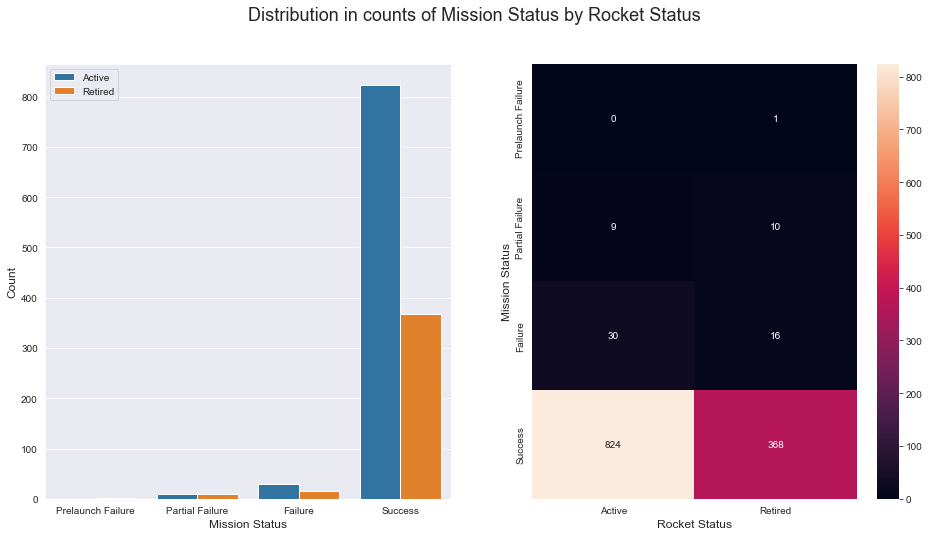

```python
bar_heat_subplots('mission_status', 'rocket_status')
```

Successful active rockets are more than twice the number of successful retired rockets with counts of 824 and 368 respectively. Active rockets which failed ('Failure') are also almost twice the number of retired failed rockets with a count of 30 and 16 respectively.

*`Mission status` vs. `Country` relationship*

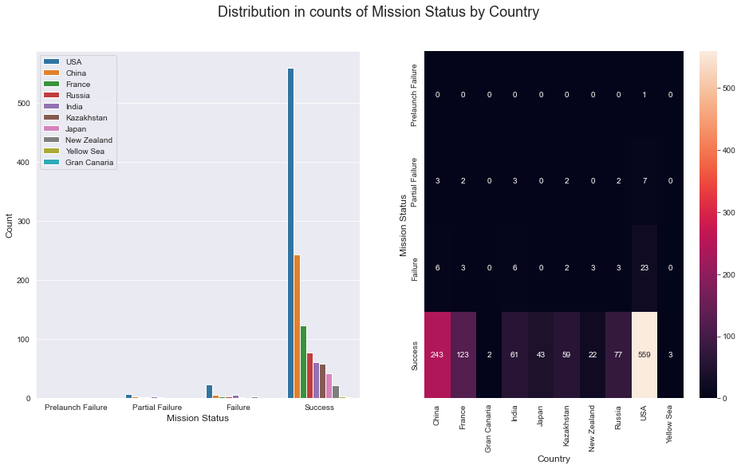

```python
bar_heat_subplots('mission_status', 'country')
```

The USA has the most successful missions which is more than twice that of China in second place with a success rate count of 559 missions to China's 243.

*`Rocket status` vs. `Country` relationship*

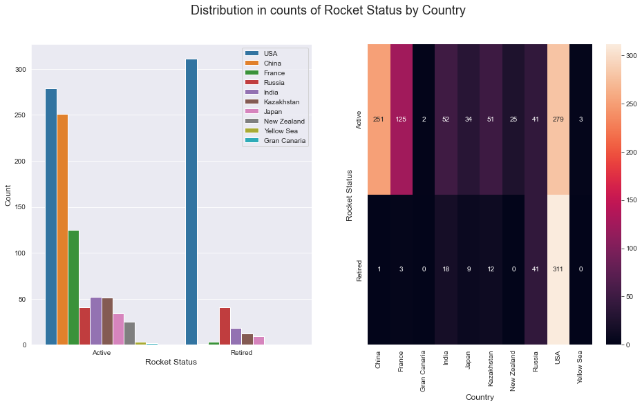

```python
bar_heat_subplots('rocket_status', 'country')
```

### Talk about some of the relationships you observed in this part of the investigation. How did the feature(s) of interest vary with other features in the dataset?

With a correlation coeeficient of *-0.410*, the relationship between year and price signifies a weak negative correlation. Increase in year sees a decrease in the price of rockets. After the year 1990, there is a significant decline in the price of rockets with the regression line indicating a downward trend over the years. From the late 2010's upwards, a high density of rockets with lower prices in use is observed.

There is no significant relationship between the feature of interest, `mission status`, and `price` as most missions were very likely to be successful and their success rates were not determined by how expensive the rocket was.

### Did you observe any interesting relationships between the other features (not the main feature(s) of interest)?

What was quite interesting was that in recent years, there have been more missions launched with countries having successfully activated their spacecrafts especially in the 2020's.

Another interesting relationship was that between rocket price and rocket status. The rocket price range of active rockets lie below 500 million USD while the rockets with the outlier price range of between 1000 - 5000 million USD have all been retired. Could cheaper or cost-effective rockets be the way forward?

*Table of Contents*

## Multivariate Exploration

In this part of the analysis, I want to explore how the two numerical variables of price and year interact in their relationship with some categorical variables such as rocket status, country and mission status.

- *Plots of the two numerical variables with a third variable color-encoded*

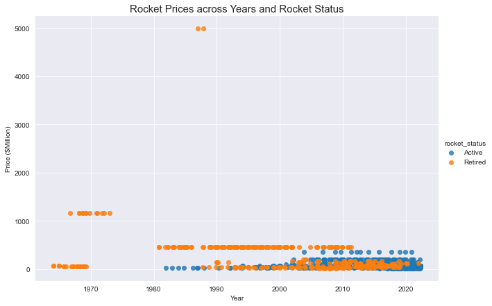

```python
# scatterplot of the two numeric variables with a color-encoded third variable (categorical)

# color-encoding the third variable, `rocket_status`, to the plot
g = sb.FacetGrid(data = space_missions_clean, hue = 'rocket_status', height=6, aspect=1.5)
g = g.map(sb.regplot, 'year', 'price', x_jitter = 0.3, fit_reg = False);
g.add_legend()
plt.xlabel('Year')
plt.ylabel('Price ($Million)');
plt.title("Rocket Prices across Years and Rocket Status", fontsize=15);
```

Rockets with prices over 1000 million dollars (i.e. 1B) have all been retired. No active rocket is close to the 1 billion dollar mark. Active rockets from the year 2000 are all below 500 million USD.

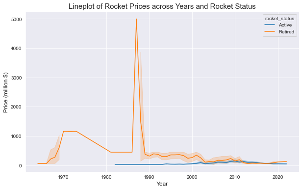

```python
# plotting a line plot with the third variable, `rocket_status`, color-encoded
plt.figure(figsize = [10, 6])
sb.lineplot(data = space_missions_clean, y = 'price', x = 'year', hue = 'rocket_status');
plt.xlabel('Year', fontsize = 12)
plt.ylabel('Price (million $)', fontsize = 12);
plt.title("Lineplot of Rocket Prices across Years and Rocket Status", fontsize=15);
```

The line plot above confirms that no active rocket is up to 500 million USD and that all rockets priced above 500 million USD are all retired. Also, rockets used for missions from the 2000's till date are so much cheaper than rockets used from the 60's through to the 90's.

> *Note!* *As about 95% of space missions were likely to successful, encoding mission status into a plot of year versus price does not generate any new or meaningful insight because, regardless of price and year, space missions were most likely to be successful than not .*
- *Mission and rocket status of countries over the years*

```python
# defining a function that plots a color-encoded third variable (categorical) against year and country
def year_pointplot(hue_var):
    """This function plots a color-encoded third variable (categorical) against year and country"""
    plt.figure(figsize=(14,5))
    ordered_country = space_missions_clean.country.value_counts().index
    if hue_var == 'mission_status':
        sb.pointplot(data = space_missions_clean, x = 'country', y = 'year', hue = hue_var,
            linestyles = "", dodge = 0.4, order = ordered_country, palette = 'Blues');
    else:
        sb.pointplot(data = space_missions_clean, x ='country', y ='year', hue='rocket_status',
             linestyles = "", dodge = 0.2, order = ordered_country)
    plt.xlabel("Country", fontsize=12)
    plt.ylabel("Year", fontsize=12);
    plt.title(f"{hue_var.replace('_', ' ').title()} of Countries over the Years", fontsize=15);
```

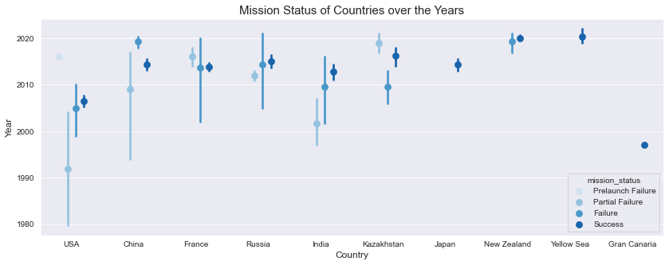

```python
year_pointplot('mission_status')
```

All countries have had successful missions especially from the late 90's till date. The USA seems to be the only country with a recorded *Prelaunch Failure* around 2016/2017. Japan, Yellow Sea and Gran Canaria are the three countries whose mission statuses showed only *Success* with no level of failure recorded.

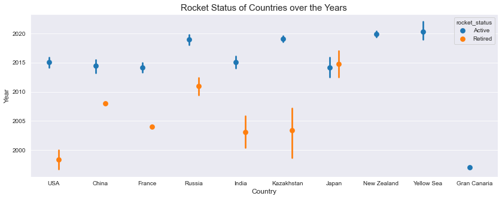

```python
year_pointplot('rocket_status')
```

- *Rocket prices of countries by rocket and mission status.*

```python
# defining a function that plots a color-encoded third variable (categorical) against price and country
def price_pointplot(hue_var):
    """This function plots a color-encoded third variable (categorical) against price and country"""
    plt.figure(figsize=(14,5))
    ordered_country = space_missions_clean.country.value_counts().index
    if hue_var == 'mission_status':
        sb.pointplot(data = space_missions_clean, x ='country', y ='price', hue = hue_var,
            linestyles = "", dodge = 0.4, order = ordered_country, palette = 'Blues');
    else:
        sb.pointplot(data = space_missions_clean, x ='country', y ='price', hue= hue_var,
            linestyles = "", dodge = 0.2, order = ordered_country);
    plt.xlabel("Country", fontsize=12)
    plt.ylabel("Price", fontsize=12);
    plt.title(f"Rocket Prices of Countries by {hue_var.replace('_', ' ').title()}", fontsize=15);
```

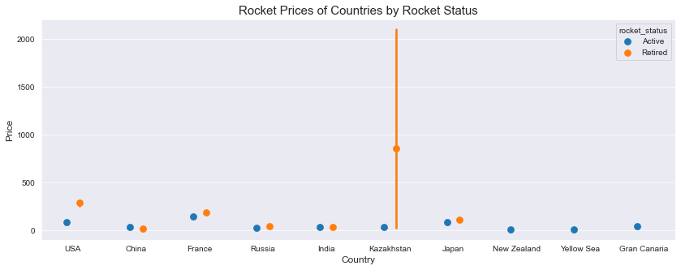

```python
price_pointplot('rocket_status')
```

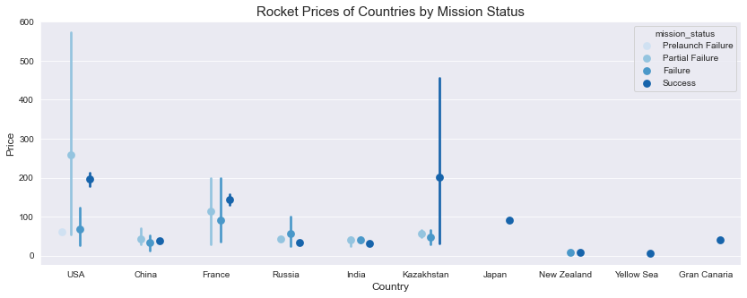

```python
price_pointplot('mission_status')
```

All New Zealand rockets seem to be the same price range of below 50 million including both its successful and failed missions. The price of Kazakhstan's successful rockets lies within the range of less than 50 to > 200 million USD. Its failed rockets were exclusively below 100 million. China's successful rockets are all below 100 million.

### Talk about some of the relationships you observed in this part of the investigation. Were there features that strengthened each other in terms of looking at your feature(s) of interest?

Rocket prices have declined over the years with rockets priced over 1000 million dollars (i.e. 1B) having been long retired. No active rocket is close to the 1 billion dollar mark; they are all below 500 million USD.

*Table of Contents*

## Conclusions

The distribution of the variable of interest, the `mission_status` shows that about 95% of all space missions were successful; indicating a very high mission success rate with the number of active rockets twice the number of retired rockets. In this dataset, which the cleaned dataset with **no null values**, the USA is the country with the most launched space missions followed by China in second place and France in the third place.

In comparison with the original dataset which has some null price values, there seems to be a resurgence in space mission programs in recent years especially in the 2020's which show the highest space mission programs in human history.

There is a weak negative correlation between year and price because after the year 1990, a significant decline in the price of rockets till date is seen. From the late 2010's upwards, a high density of rockets with lower prices in use is observed.

With an unusually high price for a rocket at 5 billion USD and the lowest price at 2.5 million dollars, most rocket prices lie below 500 million dollars. The rocket price range of active rockets lie below 500 million USD while the rockets with the outlier price range of between 1000 - 5000 million USD have all been retired. There is a very strong indication that cheaper or cost-effective rockets is the way forward in the next wave of the space race.

*Resources used during cleaning*

- [pandas.Series.dt.year](https://pandas.pydata.org/docs/reference/api/pandas.Series.dt.year.html) to extract year from date values.
- [Extracting year from pandas datetime](https://stackoverflow.com/questions/62021214/extract-year-from-pandas-datetime-column-as-numeric-value-with-nan-for-empty-cel).
- [Re-ordering columns](https://stackoverflow.com/questions/53141240/pandas-how-to-swap-or-reorder-columns).
- [Right splitting columns and adding element to new column](https://stackoverflow.com/questions/38498718/split-pandas-column-and-add-last-element-to-a-new-column).
- [Replacing commas and converting to floats](https://stackoverflow.com/questions/65510896/converting-string-to-float-in-pandas).
- [Combining date time and changing its datatype](https://stackoverflow.com/questions/17978092/combine-date-and-time-columns-using-python-pandas).

*Table of Contents*